# MVA_MR

Sai Madhuri

2024-04-12

```r
file_path <- "/Users/user/Downloads/auto-mpg.csv"
data <- read.csv(file_path)
autompg <- read.csv("/Users/user/Downloads/auto-mpg.csv")
str(autompg)
```

```
## 'data.frame':    398 obs. of  9 variables:
##  $ mpg         : num  18 15 18 16 17 15 14 14 14 15 ...
##  $ cylinders   : int  8 8 8 8 8 8 8 8 8 8 ...
##  $ displacement: num  307 350 318 304 302 429 454 440 455 390 ...
##  $ horsepower  : chr  "130" "165" "150" "150" ...
##  $ weight      : int  3504 3693 3436 3433 3449 4341 4354 4312 4425 3850 ...
##  $ acceleration: num  12 11.5 11 12 10.5 10 9 8.5 10 8.5 ...
##  $ model.year  : int  70 70 70 70 70 70 70 70 70 70 ...
##  $ origin      : int  1 1 1 1 1 1 1 1 1 1 ...
##  $ car.name    : chr  "chevrolet chevelle malibu" "buick skylark 320" "plymouth satellite" "amc rebel sst" ...
```

```r
autompg <- read.csv("/Users/user/Downloads/auto-mpg.csv")
autompg$horsepower <- as.integer(autompg$horsepower)
cleaned_auto <- na.omit(autompg)
str(autompg)
```

```
## 'data.frame':    398 obs. of  9 variables:
##  $ mpg         : num  18 15 18 16 17 15 14 14 14 15 ...
##  $ cylinders   : int  8 8 8 8 8 8 8 8 8 8 ...
##  $ displacement: num  307 350 318 304 302 429 454 440 455 390 ...
##  $ horsepower  : int  130 165 150 150 140 198 220 215 225 190 ...
##  $ weight      : int  3504 3693 3436 3433 3449 4341 4354 4312 4425 3850 ...
##  $ acceleration: num  12 11.5 11 12 10.5 10 9 8.5 10 8.5 ...
##  $ model.year  : int  70 70 70 70 70 70 70 70 70 70 ...
##  $ origin      : int  1 1 1 1 1 1 1 1 1 1 ...
##  $ car.name    : chr  "chevrolet chevelle malibu" "buick skylark 320" "plymouth satellite" "amc rebel sst" ...
```

### 1.Model Development

```r
auto<- cleaned_auto[,1:6]
# Performing multiple regression on the dataset
fit <- lm(mpg~ cylinders+displacement+horsepower+weight+acceleration, data=auto)
#show the results
summary(fit)
```

```
##
## Call:
## lm(formula = mpg ~ cylinders + displacement + horsepower + weight +
##     acceleration, data = auto)
##
## Residuals:
##      Min       1Q   Median       3Q      Max
## -11.5816  -2.8618  -0.3404   2.2438  16.3416
##
## Coefficients:
##                Estimate Std. Error t value Pr(>|t|)
## (Intercept)   4.626e+01  2.669e+00  17.331   <2e-16 ***
## cylinders    -3.979e-01  4.105e-01  -0.969   0.3330
## displacement -8.313e-05  9.072e-03  -0.009   0.9927
## horsepower   -4.526e-02  1.666e-02  -2.716   0.0069 **
## weight       -5.187e-03  8.167e-04  -6.351    6e-10 ***
## acceleration -2.910e-02  1.258e-01  -0.231   0.8171
## ---
## Signif. codes:  0 '***' 0.001 '**' 0.01 '*' 0.05 '.' 0.1 ' ' 1
##
## Residual standard error: 4.247 on 386 degrees of freedom
## Multiple R-squared:  0.7077, Adjusted R-squared:  0.7039
## F-statistic: 186.9 on 5 and 386 DF,  p-value: < 2.2e-16
```

###In this step, we loaded the auto-mpg dataset and fitted a multiple regression model using the lm() function. The model predicts the “mpg” (miles per gallon) based on several predictor variables: cylinders, displacement, horsepower, weight, acceleration.

### 2.Model Acceptance

###From the summary Pr column it is evident that weight and horsepower are the two most significant variables. R-squared value explains the fact that cylinders,displacement,horsepower,weight, acceleration variables contribute to the 70% of total variance,which is not bad. p-value< 2.2e-16 is significant so the model is acceptable.

```r
coefficients(fit)
```

```
##   (Intercept)     cylinders  displacement    horsepower        weight
##  4.626431e+01 -3.979284e-01 -8.313012e-05 -4.525708e-02 -5.186917e-03
##  acceleration
## -2.910471e-02
```

###From the above we get information about the dependent variable mpg in equation form y=b0+ b1x1 + b2x2+…+bnxn where intercept b0=4.626431e+01, and cofficients b1=-3.979284e-01,….

```r
confint(fit,level=0.95)
```

```
##                     2.5 %       97.5 %
## (Intercept)  41.015911401 51.512704304
## cylinders    -1.205111478  0.409254760
## displacement -0.017919421  0.017753161
## horsepower   -0.078016480 -0.012497680
## weight       -0.006792548 -0.003581286
## acceleration -0.276367486  0.218158058
```

```r
fitted(fit)
```

[output not shown]

[output cut: 43 more lines]

[output not shown]

### 3.Residual Analysis

```r
library(GGally)
```

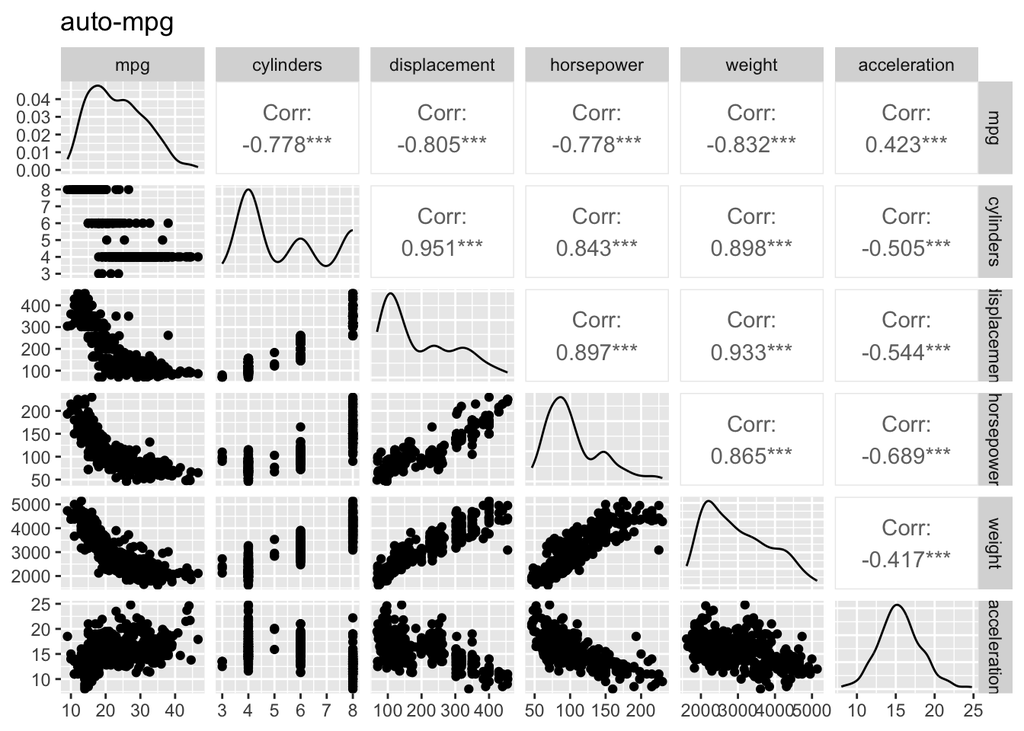

```r
ggpairs(data=auto, title="auto-mpg")
```

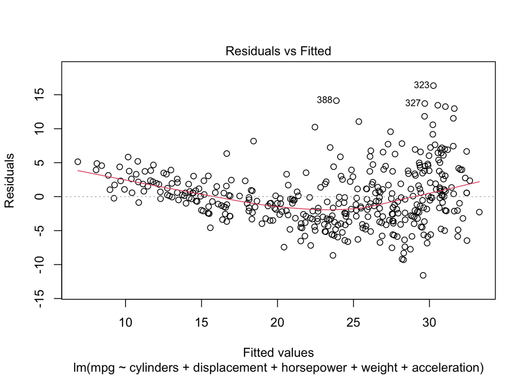

```r
plot(fit, which=1) # Residuals vs Fitted
```

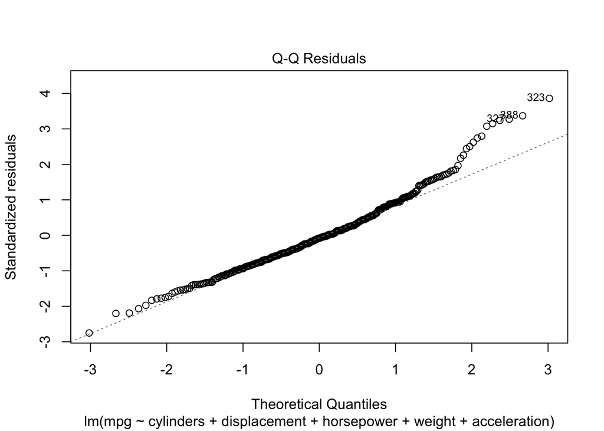

```r
plot(fit, which=2) # Normal Q-Q plot
```

```r
residuals <- residuals(fit)
```

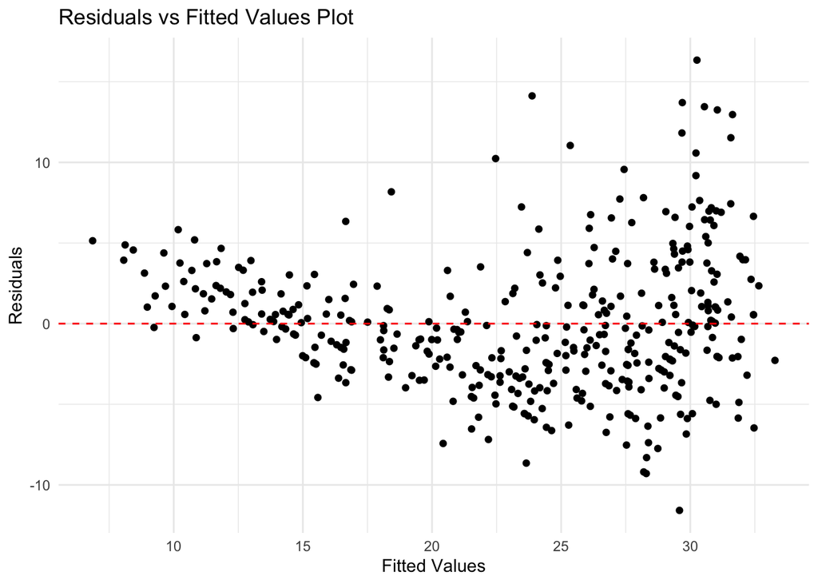

```r
#Plot residuals against fitted values to check for homoscedasticity
plot_resid_fitted <- ggplot() +
  geom_point(aes(x = fitted(fit), y = residuals)) +
  geom_hline(yintercept = 0, linetype = "dashed", color = "red") +
  labs(x = "Fitted Values", y = "Residuals",
       title = "Residuals vs Fitted Values Plot") +
  theme_minimal()
print(plot_resid_fitted)
```

### 4.Prediction

```r
predict.lm(fit, data.frame(cylinders=8, displacement=310, horsepower=170, weight=4300,
    acceleration=9) )
```

```
##        1
## 12.79572
```

##Here when random values are given to the independent variables cylinders,displacement, horsepower, weight and acceleration, the model predicted the dependent variable mpg would be 12.79.

### 5.Model Accuracy

```r
#Make predictions using the model
predicted <- predict(fit, newdata = auto)
```

```r
#Calculating RMSE by taking the square root of the mean of the squared differences between the actual values (auto$mpg) and the predicted values (predicted)
rmse <- sqrt(mean((auto$mpg - predicted)^2))
rmse
```

```
## [1] 4.214427
```

#RMSE measures the average deviation of predicted from actual values.

#Conclusion: Here the moderate RMSE value 4.21 suggests that the model is having resonable accuracy but with noticeable deviations from actual values.

### Some Visualizations

```r
library(car)
```

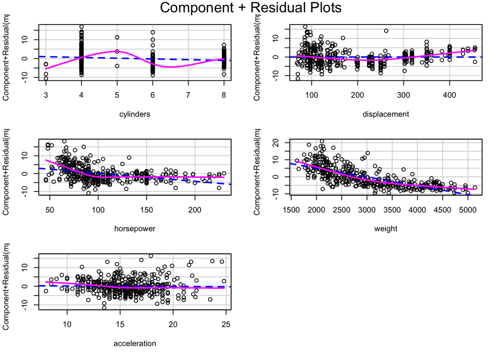

```r
#Nonlinearity
# component + residual plot
crPlots(fit)
```

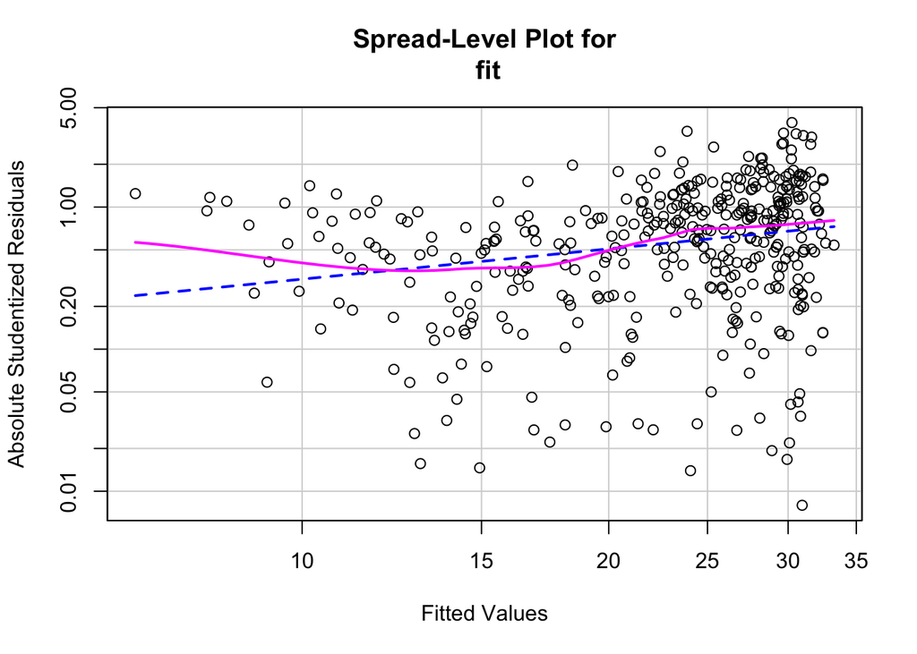

```
##
## Suggested power transformation:  0.2920186
```

```r
# plot studentized residuals vs. fitted values
library(car)
spreadLevelPlot(fit)
```